# Ford GoBike System Data

## by: Mohamed Eltedawy

## Preliminary Wrangling

> This data set includes information about individual rides made in a bike-sharing system covering the greater San Francisco Bay area.

### What is the structure of your dataset?

> I didn't find any duplicated values but there are some missing values in some columns, like the start and end stations id and name, and also the gender and birth year for the members.

> Most of features about the time of the trip begining and ending, and also where the trip start and end and some informations about the bike and the user.

### What is/are the main feature(s) of interest in your dataset?

> I'm interested in figuring out how trip duration is dependent on other specifications from the dataset.

### What features in the dataset do you think will help support your investigation into your feature(s) of interest?

> I expect that the trip durations highly depend on duration_sec column, but I'll explore some features like user_type , some columns I created from the orignal columns and explore the relationships in the dataset.

## Univariate Exploration

> In this section, investigate distributions of individual variables. If you see unusual points or outliers, take a deeper look to clean things up and prepare yourself to look at relationships between variables.

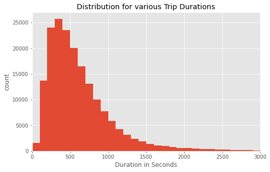

> We can see that the distribution for average trip durations is right-skewed, so we will take logarithmic transformation for x-axis.  
> Calculating the average for trip durations in seconds seems not informative, so we can change into minutes and after that apply transformation

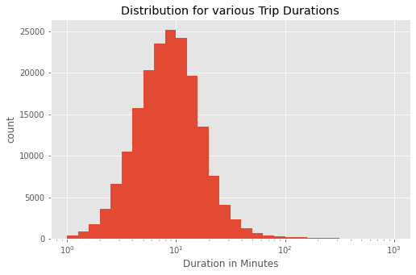

> We can now easily interpret the plot, most of trips seem to be short trips which the duration for trips is around 10 minutes.

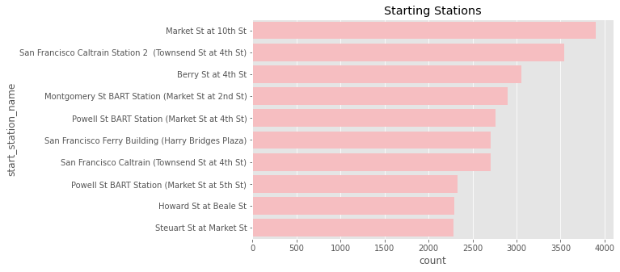

> We can see that Market St at 10th St seems that most of trips started from it also San Francisco Caltrain Station 2, Berry St at 4th St came after it.

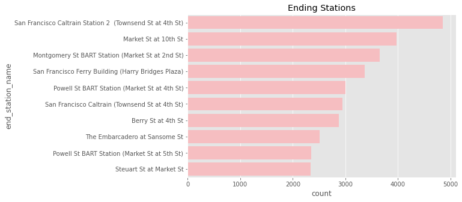

> We can see that San Francisco Caltrain Station 2 is the most ending station for trips.

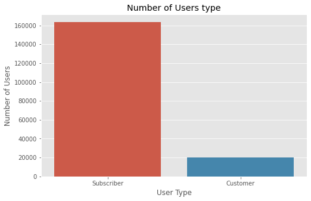

> we can see most of users are Subscriber.

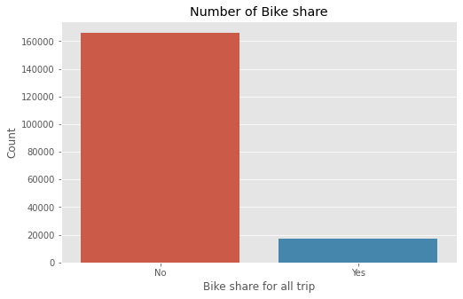

> We can see that most of users don't share the bike for all trip.

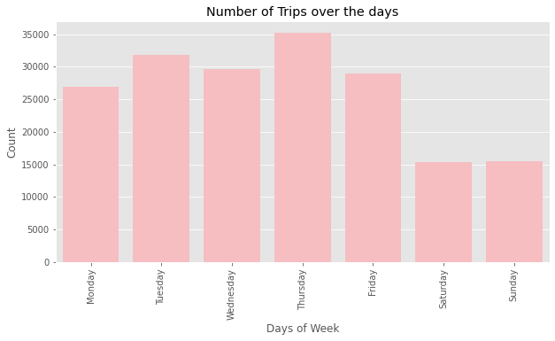

> Over February, Most of trips are on Thursday and on Sunday and Saturday the small number of trips.

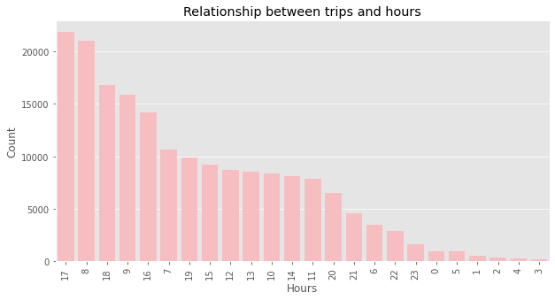

> We can see that most of trips start at 17 and 8 o'clock, maybe these hours are the start and end of work.

### Discuss the distribution(s) of your variable(s) of interest. Were there any unusual points? Did you need to perform any transformations?

> the data show a great visualization and give me more insights about the data but it needs more data and data for difference months and years to be more generalize but here the data for only one month. But in the next exploration i will make more data exploration and i hope that give more insights.

### Of the features you investigated, were there any unusual distributions? Did you perform any operations on the data to tidy, adjust, or change the form of the data? If so, why did you do this?

> No, I didn't change the shape of data I only take logarithmic transformation for the duration_sec column after I calculated from it the minutes.

## Bivariate Exploration

> In this section, investigate relationships between pairs of variables in your data. Make sure the variables that you cover here have been introduced in some fashion in the previous section (univariate exploration).

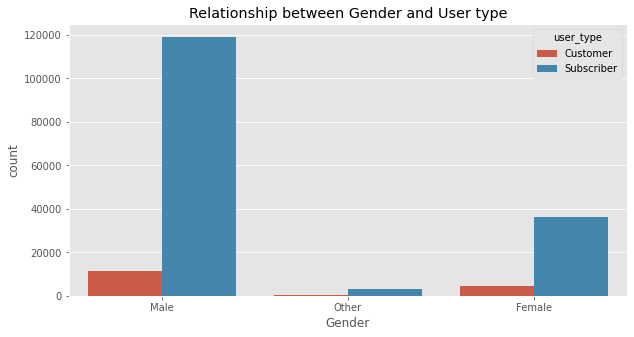

> We can see that male are more than female in both types.

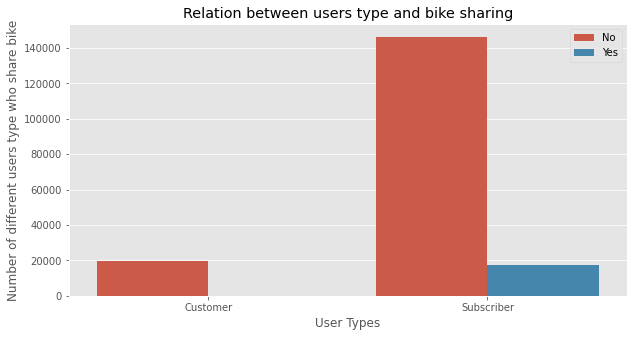

> After the plot and the query, we can see that no one from the customers share the bike for all trip and all people who share bike for all trip are subscribers.

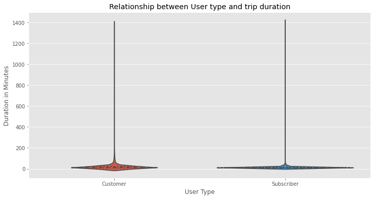

> From the plot we can see that there are lots of outliers, we will consider outliers are the minutes after 60

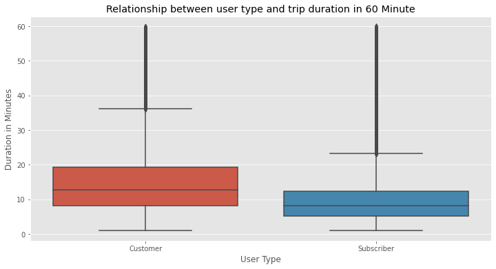

> We can see the average trip duration for customer is higher than subscriber.  
> We can also say that subscriber's trip seems to be short at time.  
> Violin plots seem to be more difficult than boxplot at interpretation so I didn't use it here.

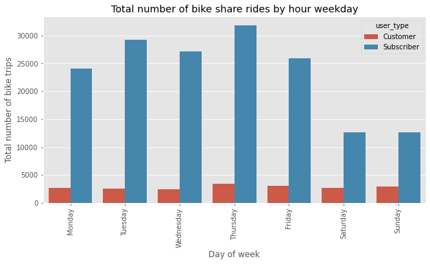

> From the plot for the subscribers users, we can see the effect of weekends on Sunday and Saturday, on the other hand for the customer they don't have weekends effect, the usage for them is consistent.

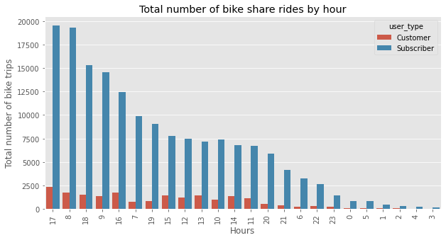

> From the plot for subscriber the peaks for them are centered around commute times (5pm,8am,6pm,9am), on the other hand for customer the peak for them are centered around (5pm ,8am) and the rest of hours look similer no big difference only from(0 am to 5 am)

### Did you observe any interesting relationships between the other features (not the main feature(s) of interest)?

> Only the subscribers share bikes for all trip.

## Multivariate Exploration

> Create plots of three or more variables to investigate your data even further. Make sure that your investigations are justified, and follow from your work in the previous sections.

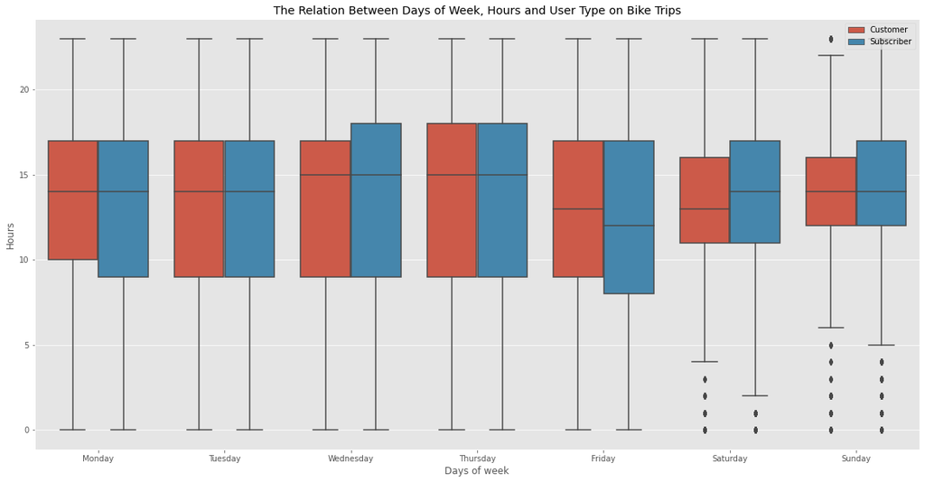

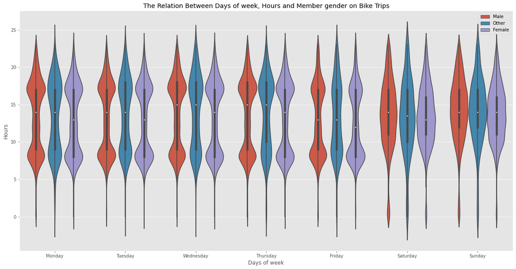

### Were there any interesting or surprising interactions between features?

[output not shown]

[output cut: 75 more lines]

[output not shown]